# Yampa

Brian

2/2/2023

NOTES FROM SF:

FOR STEAMBOAT, COMPARE THE DETRENDED CLIAMTE NORMAL CURVES AGAINST EACH OTHER

Derry & fassnacht 2010 Compare climatology of snotel statuions= they don’t have the same climatol9ogy based on the snow data

Figure 5b - https://agupubs.onlinelibrary.wiley.com/doi/10.1029/2009WR007835

# Disclaimer

*This work is very preliminary as I get back into the coding swing of things. Data wrangling and figure generation will be done via R, but the rest of the project will be done using good ol’ microsoft products. This is just an entry point into data crunching and should by no means be considered a final product.*

*Also, I’m not great at this but whatever. I could automate this, but I’ll figure that out shortly!*

**Need to update figures & analyze sites for seasonal trends**

# Methodology

SNOTEL data was provided by the NRCS. Data was cleaned by removing outliers that are likely implausible; any year with more than 15 observations missing was removed. Temperatures were adjusted using the Morrisey method for stations identified by Ma et al (2019) due to SNOTEL temperature sensor changes, with the adjustment applied to pre-sensor change data. Daily mean observations were detrended to determine whether values were increasing or decreasing from the entire time series trend. Daily mean temperatures were first averaged by water year, with all water year means then averaged by day of water year. The mean temperature by day for the period of record was averaged. To find the standard deviation, the daily mean temperatures by water year was subtracted from the averaged mean temperature by day for the period of record. All water year means averaged by day of water year were subtracted from the temperature mean. The resulting values were then added together to find the “residual” of the daily mean temperatures by water year. The standard deviation was then computed from those residuals, with trends analyzed by Mann‐Kendall significance test and Theil‐Sen’s rate of change. Significant trends are identified with p-values of less than 0.10.

Morrisey Method

The Morrisey Method is taken from [Ma, Fassnacht and Kampf.](https://agupubs.onlinelibrary.wiley.com/doi/epdf/10.1029/2019WR025921).

**In the Ma et al. spreadsheet, H1 is Morrisey, H2 is Oiler**

Yampa Area SNOTEL sites:

Burro Mountain 378 *NSCE- Original, Bias- Morrisey* 7/11/2002 (NSCE- 0.87 vs 0.84)

Columbine 408 *Morrisey* 7/22/2005

Columbine Pass 409 *Morrisey* 6/23/2005

Crosho 426 *Morrisey* 7/21/2005

Dry Lake 457 *Oyler -> Morrisey* 7/30/2003

Elk River 467 *Oyler -> Morrisey* 8/7/2006

Lynx Pass 607 *Morrisey* 5/22/2006

Rabbit Ears 709 *Morrisey* 8/7/2006

Ripple Creek 717 *Oyler -> Morrisey* 8/7/2006

Tower 825 *Original* 8/18/2004

Trapper Lake 827 *Original* 12/13/2004

## Data from thesis research:

```
SNOTEL_yampa_area <- snotel_download(site_id = c(378, 408, 409, 426, 457, 467, 607, 709, 717, 825, 827), path = tempdir('../data'), internal = TRUE)

write.csv(SNOTEL_yampa_area,"C:/Users/13074/Documents/ESS580/thesis_project/Yampa/data_raw/snotel_yampa.csv", row.names = FALSE) #write in the raw data
```

```r
SNOTEL_yampa_area <- read.csv("C:/Users/13074/Documents/ESS580/thesis_project/Yampa/data_raw/snotel_yampa.csv", header = TRUE)
```

# Burro Mountain 378

*NSCE- Original, Bias- Morrisey* 7/11/2002

```r
snotel_378 <- SNOTEL_yampa_area %>%
  filter(site_id == "378")
```

```r
#str(snotel_378) # check the date, usually a character.

snotel_378$Date <- as.Date(snotel_378$date) #change date from character to date format, capitalize to work with Water year functon from NWIS.

#THIS WILL CHANGE FOR EACH STATION
snotel_378_clean <- snotel_378 %>% # filter for the timeframe
  filter(Date >= "1979-10-01" & Date <= "2022-09-30") %>%
  #filter(temperature_mean >= -30 & temperature_mean <= 20) %>% # removing outliers
  addWaterYear() %>%
  mutate(daymonth = format(as.Date(Date), "%d-%m")) %>%
  na.omit()

#adding water day using difftime (SUPER COOL. example from [this](https://stackoverflow.com/questions/48123049/create-day-index-based-on-water-year))

snotel_378_clean <- snotel_378_clean %>%
  group_by(waterYear)%>%
  mutate(waterDay = (as.integer(difftime(Date, ymd(paste0(waterYear - 1 ,'-09-30')), units = "days"))))
```

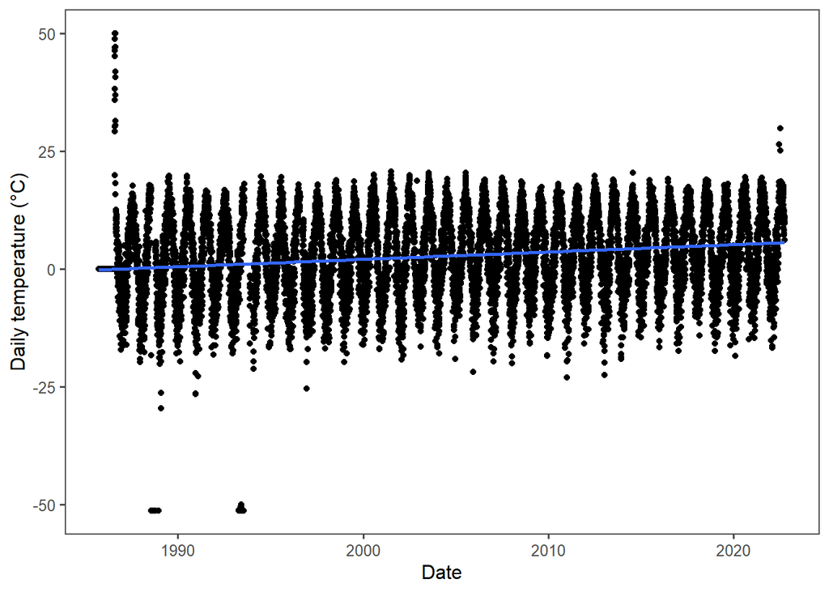

```r
# Check for outliers

ggplot(snotel_378_clean, aes(x = Date, y = temperature_mean)) +
  geom_point() + #lwd = 2) +
  theme_few() +
  geom_smooth(method = "lm", se=FALSE) +
  ylab('Daily temperature (°C)') +
  xlab('Date')
```

```r
snotel_378_clean <- snotel_378_clean %>%
  mutate(temp_diff = abs(temperature_min - temperature_max)) %>%
  filter(temperature_mean > -40)# %>%
  #filter(temperature_mean < 25)
```

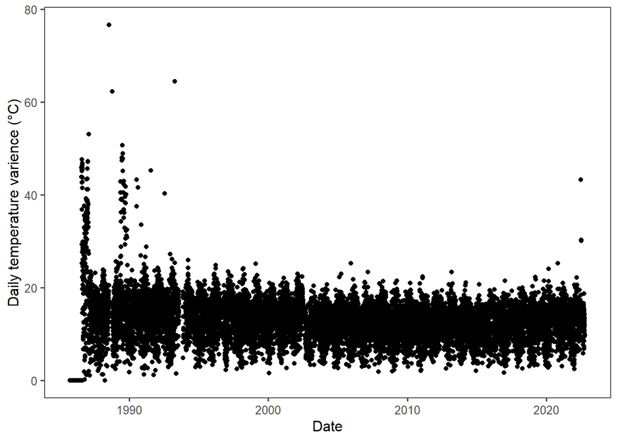

```r
ggplot(snotel_378_clean, aes(x = Date, y = temp_diff)) +
  geom_point() + #lwd = 2) +
  theme_few() +
  #geom_smooth(method = "lm", se=FALSE) +
  ylab('Daily temperature varience (°C)') +
  xlab('Date')
```

Per Steven’s advice: :If there are more than 15 missing days, then…remove that year”

```r
# filtering for temperature anomalies
#snotel_378_cull_count <- snotel_378_clean %>%
#  filter(temperature_min > -40) %>%
#  count(waterYear)

#snotel_378_cull_count

# filtering for too few observations in a year
snotel_378_cull_count_days <- snotel_378_clean %>%
  group_by(waterYear) %>%
  count(waterYear) %>%
  filter(n < 350)

snotel_378_cull_count_days
```

```
## # A tibble: 10 x 2
## # Groups:   waterYear [10]
##    waterYear     n
##        <dbl> <int>
##  1      1985     1
##  2      1988   298
##  3      1989   341
##  4      1993   281
##  5      1994   261
##  6      1995   344
##  7      1996   320
##  8      2002   312
##  9      2016   310
## 10      2022   338
```

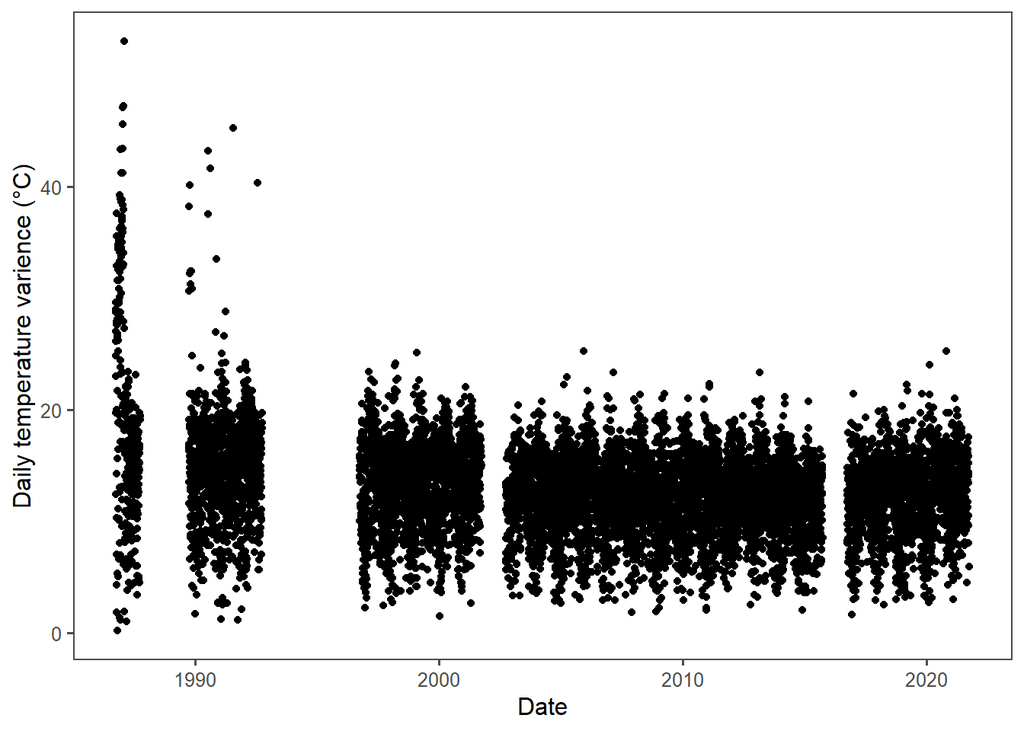

```r
snotel_378_clean_culled <- snotel_378_clean %>%
  filter(waterYear != "1985" & waterYear != "1986" & waterYear != "1988" & waterYear != "1989" & waterYear != "1993" & waterYear != "1994" & waterYear != "1995" & waterYear != "1996" & waterYear != "2002" & waterYear != "2016" & waterYear != "2022")# & waterYear != "2017") #%>%
  #filter(temperature_mean > -49)

ggplot(snotel_378_clean_culled, aes(x = Date, y = temp_diff)) +
  geom_point() + #lwd = 2) +
  theme_few() +
  #geom_smooth(method = "lm", se=FALSE) +
  ylab('Daily temperature varience (°C)') +
  xlab('Date')
```

Culling WY 1986 as well.

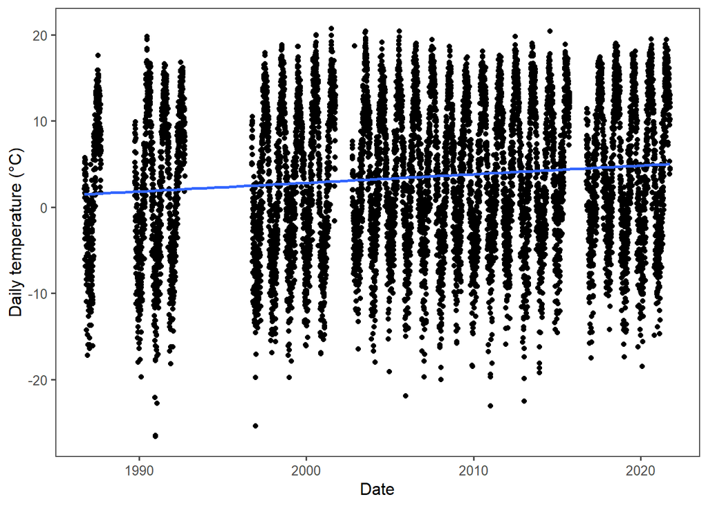

```r
ggplot(snotel_378_clean_culled, aes(x = Date, y = temperature_mean)) +
  geom_point() + #lwd = 2) +
  theme_few() +
  geom_smooth(method = "lm", se=FALSE) +
  ylab('Daily temperature (°C)') +
  xlab('Date')
```

```r
temp_378_xts <- xts(snotel_378_clean_culled$temperature_mean, order.by = snotel_378_clean_culled$Date)

dygraph(temp_378_xts) %>%
  dyAxis("y", label = "Daily mean temperature (°C)")
```

[interactive chart not shown]

```r
#snotel_378_clean_culled <- snotel_378_clean_culled %>%
#  filter(temperature_mean < 19.3)

temp_378_xts <- xts(snotel_378_clean_culled$temperature_mean, order.by = snotel_378_clean_culled$Date)

dygraph(temp_378_xts) %>%
  dyAxis("y", label = "Daily mean temperature (°C)")
```

[interactive chart not shown]

### Burro Mountain 378

*NSCE- Original, Bias- Morrisey* 7/11/2002

```r
snotel_378_adjusted <- snotel_378_clean_culled %>%
  mutate(temp_ad = if_else(Date < "2002-07-11", ((5.3*10^(-7))*(temperature_mean^(4))+(3.72*10^(-5))*(temperature_mean^(3))-(2.16*10^(-3))*(temperature_mean^(2))-(7.32*10^(-2))*(temperature_mean)+1.37)+temperature_mean, temperature_mean))
```

Non-corrected

#### 378 Detrended

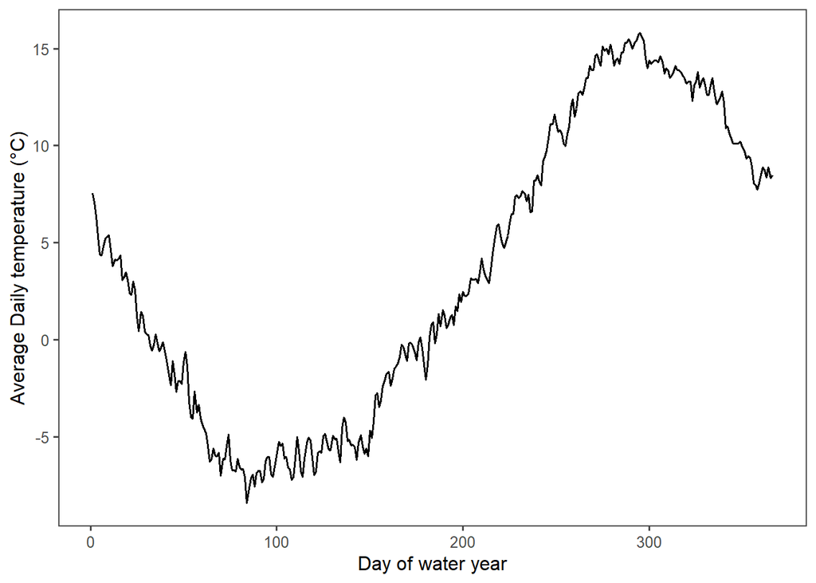

```r
#using the clean culled df:

#average water year temperature

yearly_wy_aver_378 <- snotel_378_adjusted %>%
  group_by(waterYear) %>%
  mutate(aver_ann_temp = mean(temperature_mean))

#Average temperature by day for all water years:

daily_wy_aver_378 <- yearly_wy_aver_378 %>%
  group_by(daymonth) %>%
  mutate(aver_day_temp = mean(aver_ann_temp))

#average mean temperature by day for the period of record:

daily_wy_aver_378 <- daily_wy_aver_378 %>%
  group_by(daymonth) %>%
  mutate(all_ave_temp = mean(daily_wy_aver_378$aver_day_temp))

# try to show all years as means.
daily_wy_aver2_378 <-daily_wy_aver_378 %>%
  group_by(waterDay) %>%
  mutate(date_temp = mean(temperature_mean))


daily_wy_aver2_378$date_temp <- signif(daily_wy_aver2_378$date_temp,3) #reduce the sig figs


ggplot(daily_wy_aver2_378, aes(x = waterDay, y = date_temp))+
  geom_line(size= 0.7) +
  theme_few() +
  ylab('Average Daily temperature (°C)') +
  xlab('Day of water year')
```

#### 378 SD

```r
standard_dev_378 <- daily_wy_aver_378 %>%
  group_by(waterYear) %>%
  mutate(residual = (all_ave_temp-aver_ann_temp)+temperature_mean-aver_day_temp) %>%
  mutate(deviation = abs(residual-lag(residual)))

standard_dev_all_378 <- standard_dev_378 %>%
  group_by(waterYear) %>%
  mutate(nmbr = n())

standard_dev_all_378 <- standard_dev_all_378 %>%
  group_by(waterYear) %>%
  mutate(resid_mean = mean(residual)) %>%
  mutate(sd_1 = residual-resid_mean) %>%
  mutate(sd_2 = (((sum((sd_1)^2))/((nmbr-1))))^(0.5)) %>%
  distinct(sd_2, .keep_all = TRUE) %>%
   select(waterYear, sd_2)

standard_dev_all_378 %>%
  kable(.,'html') %>%
  kable_styling() %>%
  scroll_box(width='250px',height='500px')
```

| waterYear | sd_2 |
| --- | --- |
| 1987 | 8.562568 |
| 1990 | 9.114355 |
| 1991 | 9.254156 |
| 1992 | 8.275786 |
| 1997 | 8.898932 |
| 1998 | 8.983050 |
| 1999 | 8.073327 |
| 2000 | 8.686540 |
| 2001 | 9.301471 |
| 2003 | 8.509538 |
| 2004 | 8.017044 |
| 2005 | 7.723002 |
| 2006 | 8.547829 |
| 2007 | 8.796189 |
| 2008 | 8.749038 |
| 2009 | 7.771973 |
| 2010 | 8.617066 |
| 2011 | 8.282002 |
| 2012 | 8.445614 |
| 2013 | 8.991985 |
| 2014 | 8.166025 |
| 2015 | 7.657629 |
| 2017 | 8.034586 |
| 2018 | 8.020621 |
| 2019 | 8.518154 |
| 2020 | 8.848254 |
| 2021 | 8.718771 |

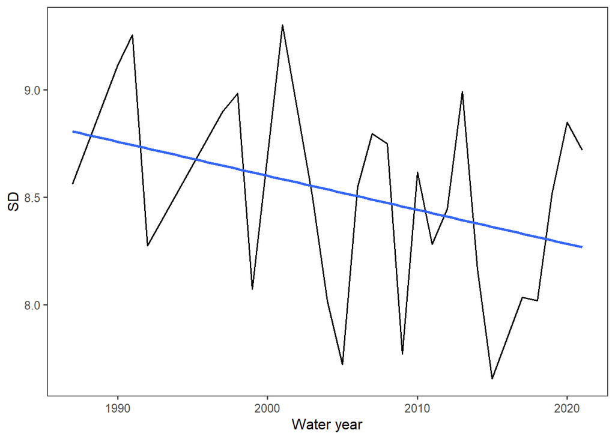

```r
ggplot(standard_dev_all_378, aes(x = waterYear, y = sd_2))+
  geom_line(size= 0.7) +
  theme_few() +
  geom_smooth(method = "lm", se=FALSE) +
  ylab('SD') +
  xlab('Water year')
```

#### MK & SS for 378 (non-corrected)

```r
sd_mk_378 <- mk.test(standard_dev_all_378$sd_2)
print(sd_mk_378)
```

```
##
##  Mann-Kendall trend test
##
## data:  standard_dev_all_378$sd_2
## z = -1.5427, n = 27, p-value = 0.1229
## alternative hypothesis: true S is not equal to 0
## sample estimates:
##            S         varS          tau
##  -75.0000000 2301.0000000   -0.2136752
```

```r
sd_sens_378 <- sens.slope(standard_dev_all_378$sd_2)
print(sd_sens_378)
```

```
##
##  Sen's slope
##
## data:  standard_dev_all_378$sd_2
## z = -1.5427, n = 27, p-value = 0.1229
## alternative hypothesis: true z is not equal to 0
## 95 percent confidence interval:
##  -0.047456119  0.006621254
## sample estimates:
## Sen's slope
##  -0.0230883
```

#### 378 Detrended (corrected)

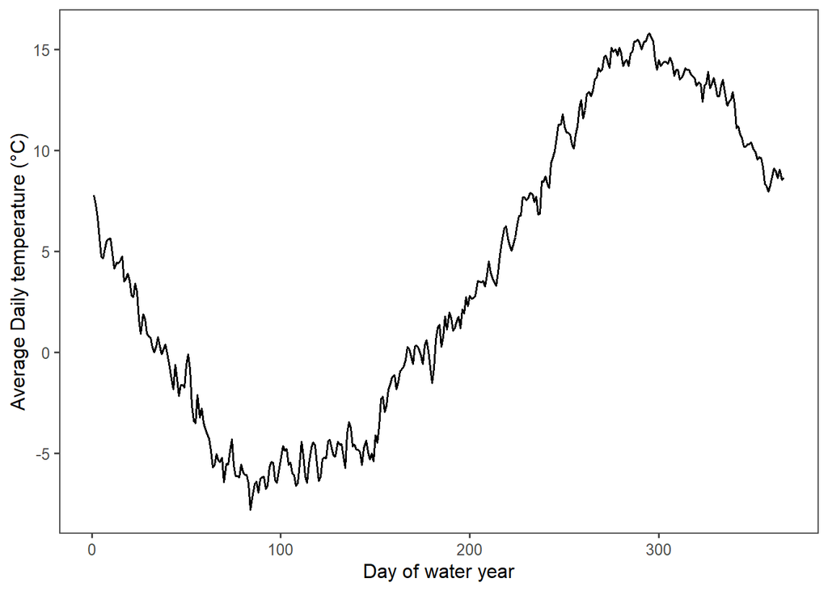

```r
#using the clean culled df:
#average water year temperature
yearly_wy_aver_378_ad <- snotel_378_adjusted %>%
  group_by(waterYear) %>%
  mutate(aver_ann_temp_ad = mean(temp_ad))
#Average temperature by day for all water years:
daily_wy_aver_378_ad <- yearly_wy_aver_378_ad %>%
  group_by(daymonth) %>%
  mutate(aver_day_temp_ad = mean(aver_ann_temp_ad))
#average mean temperature by day for the period of record:
daily_wy_aver_378_ad <- daily_wy_aver_378_ad %>%
  group_by(daymonth) %>%
  mutate(all_ave_temp_ad = mean(daily_wy_aver_378_ad$aver_day_temp_ad))
# try to show all years as means.
daily_wy_aver2_378_ad <-daily_wy_aver_378_ad %>%
  group_by(waterDay) %>%
  mutate(date_temp_ad = mean(temp_ad))

daily_wy_aver2_378_ad$date_temp_ad <- signif(daily_wy_aver2_378_ad$date_temp_ad,3) #reduce the sig figs
ggplot(daily_wy_aver2_378_ad, aes(x = waterDay, y = date_temp_ad))+
  geom_line(size= 0.7) +
  theme_few() +
  ylab('Average Daily temperature (°C)') +
  xlab('Day of water year')
```

#### 378 SS (corrected)

```r
standard_dev_378_ad <- daily_wy_aver_378_ad %>%
  group_by(waterYear) %>%
  #filter(waterYear >= 1987 & waterYear <= 2021) %>%
  mutate(residual = (all_ave_temp_ad-aver_ann_temp_ad)+temp_ad-aver_day_temp_ad) %>%
  mutate(deviation = abs(residual-lag(residual)))
standard_dev_all_378_ad <- standard_dev_378_ad %>%
  group_by(waterYear) %>%
  mutate(nmbr = n())
standard_dev_all_378_ad <- standard_dev_all_378_ad %>%
  group_by(waterYear) %>%
  mutate(resid_mean = mean(residual)) %>%
  mutate(sd_1 = residual-resid_mean) %>%
  mutate(sd_2 = (((sum((sd_1)^2))/((nmbr-1))))^(0.5)) %>%
  distinct(sd_2, .keep_all = TRUE) %>%
   select(waterYear, sd_2)
standard_dev_all_378_ad %>%
  kable(.,'html') %>%
  kable_styling() %>%
  scroll_box(width='250px',height='500px')
```

| waterYear | sd_2 |
| --- | --- |
| 1987 | 7.940547 |
| 1990 | 8.436056 |
| 1991 | 8.633602 |
| 1992 | 7.670874 |
| 1997 | 8.260208 |
| 1998 | 8.299486 |
| 1999 | 7.471734 |
| 2000 | 7.993287 |
| 2001 | 8.584377 |
| 2003 | 8.508522 |
| 2004 | 8.016141 |
| 2005 | 7.722598 |
| 2006 | 8.547499 |
| 2007 | 8.795362 |
| 2008 | 8.748133 |
| 2009 | 7.771479 |
| 2010 | 8.616338 |
| 2011 | 8.281602 |
| 2012 | 8.444783 |
| 2013 | 8.991116 |
| 2014 | 8.165236 |
| 2015 | 7.657576 |
| 2017 | 8.034186 |
| 2018 | 8.019986 |
| 2019 | 8.517552 |
| 2020 | 8.847387 |
| 2021 | 8.717958 |

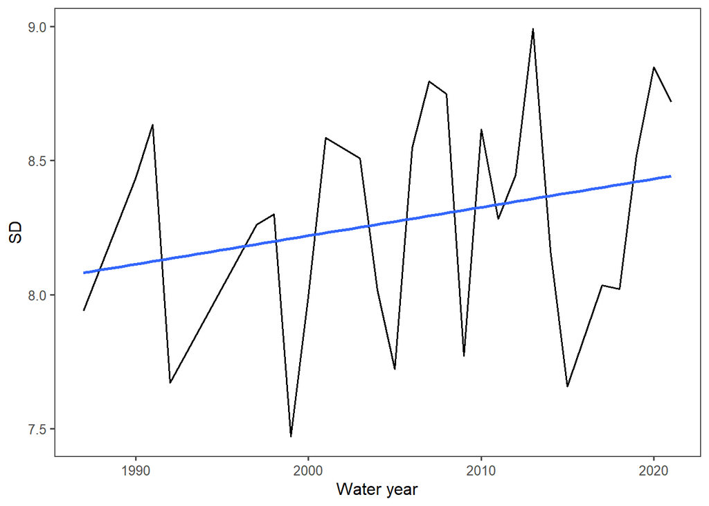

```r
ggplot(standard_dev_all_378_ad, aes(x = waterYear, y = sd_2))+
  geom_line(size= 0.7) +
  theme_few() +
  geom_smooth(method = "lm", se=FALSE) +
  ylab('SD') +
  xlab('Water year')
```

#### MK & SS 378 (corrected)

```r
sd_mk_378_ad <- mk.test(standard_dev_all_378_ad$sd_2)
print(sd_mk_378_ad)
```

```
##
##  Mann-Kendall trend test
##
## data:  standard_dev_all_378_ad$sd_2
## z = 1.3342, n = 27, p-value = 0.1821
## alternative hypothesis: true S is not equal to 0
## sample estimates:
##            S         varS          tau
##   65.0000000 2301.0000000    0.1851852
```

```r
sd_sens_378_ad <- sens.slope(standard_dev_all_378_ad$sd_2)
print(sd_sens_378_ad)
```

```
##
##  Sen's slope
##
## data:  standard_dev_all_378_ad$sd_2
## z = 1.3342, n = 27, p-value = 0.1821
## alternative hypothesis: true z is not equal to 0
## 95 percent confidence interval:
##  -0.009653315  0.035911433
## sample estimates:
## Sen's slope
##  0.01222034
```

# Columbine 408

*Morrisey* 7/22/2005

```r
snotel_408 <- SNOTEL_yampa_area %>%
  filter(site_id == "408")
```

```r
#str(snotel_408) # check the date, usually a character.

snotel_408$Date <- as.Date(snotel_408$date) #change date from character to date format, capitalize to work with Water year functon from NWIS.

#THIS WILL CHANGE FOR EACH STATION
snotel_408_clean <- snotel_408 %>% # filter for the timeframe
  filter(Date >= "1979-10-01" & Date <= "2022-09-30") %>%
  #filter(temperature_mean >= -30 & temperature_mean <= 20) %>% # removing outliers
  addWaterYear() %>%
  mutate(daymonth = format(as.Date(Date), "%d-%m")) %>%
  na.omit()

#adding water day using difftime (SUPER COOL. example from [this](https://stackoverflow.com/questions/48123049/create-day-index-based-on-water-year))

snotel_408_clean <- snotel_408_clean %>%
  group_by(waterYear)%>%
  mutate(waterDay = (as.integer(difftime(Date, ymd(paste0(waterYear - 1 ,'-09-30')), units = "days"))))
```

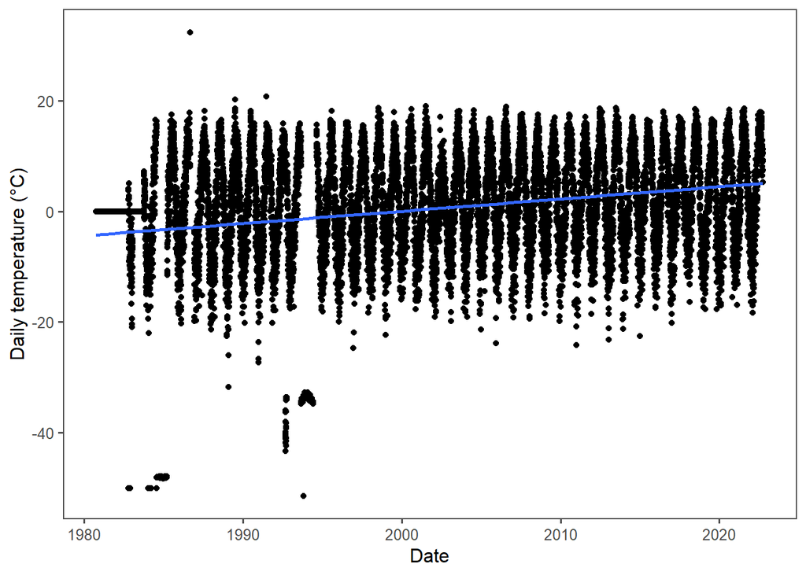

```r
# Check for outliers

ggplot(snotel_408_clean, aes(x = Date, y = temperature_mean)) +
  geom_point() + #lwd = 2) +
  theme_few() +
  geom_smooth(method = "lm", se=FALSE) +
  ylab('Daily temperature (°C)') +
  xlab('Date')
```

```r
snotel_408_clean <- snotel_408_clean %>%
  mutate(temp_diff = abs(temperature_min - temperature_max)) %>%
  filter(temperature_mean > -40)# %>%
  #filter(temperature_mean < 25)
```

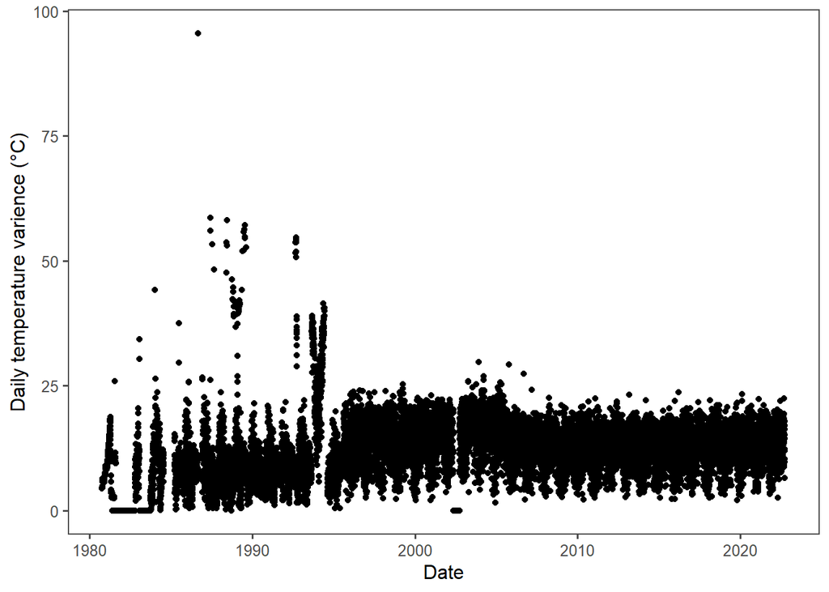

```r
ggplot(snotel_408_clean, aes(x = Date, y = temp_diff)) +
  geom_point() + #lwd = 2) +
  theme_few() +
  #geom_smooth(method = "lm", se=FALSE) +
  ylab('Daily temperature varience (°C)') +
  xlab('Date')
```

Per Steven’s advice: :If there are more than 15 missing days, then…remove that year”

```r
# filtering for temperature anomalies
#snotel_408_cull_count <- snotel_408_clean %>%
#  filter(temperature_min > -40) %>%
#  count(waterYear)

#snotel_408_cull_count

# filtering for too few observations in a year
snotel_408_cull_count_days <- snotel_408_clean %>%
  group_by(waterYear) %>%
  count(waterYear) %>%
  filter(n < 350)

snotel_408_cull_count_days
```

```
## # A tibble: 8 x 2
## # Groups:   waterYear [8]
##   waterYear     n
##       <dbl> <int>
## 1      1981   343
## 2      1983   317
## 3      1984   234
## 4      1985   195
## 5      1986   336
## 6      1987   298
## 7      1994   272
## 8      2002   347
```

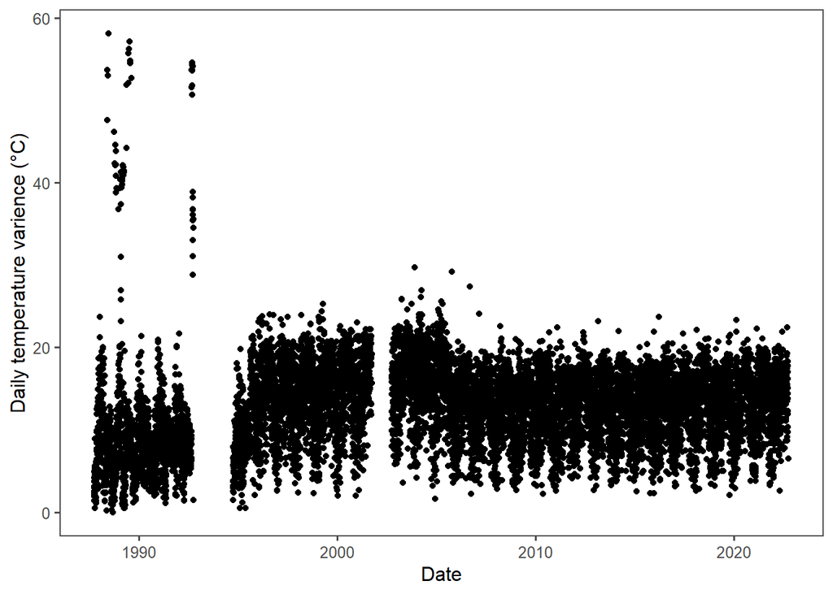

```r
snotel_408_clean_culled <- snotel_408_clean %>%
  filter(waterYear > "1987" & waterYear != "1993" & waterYear != "1994" & waterYear != "2002")# & waterYear != "1985" & waterYear != "1986" & waterYear != "1987" & waterYear != "1994" & waterYear != "2002")# & waterYear != "2002" & waterYear != "2016" & waterYear != "2022")# & waterYear != "2017") #%>%
  #filter(temperature_mean > -49)

ggplot(snotel_408_clean_culled, aes(x = Date, y = temp_diff)) +
  geom_point() + #lwd = 2) +
  theme_few() +
  #geom_smooth(method = "lm", se=FALSE) +
  ylab('Daily temperature varience (°C)') +
  xlab('Date')
```

Culling WY 1986 & 1993 as well.

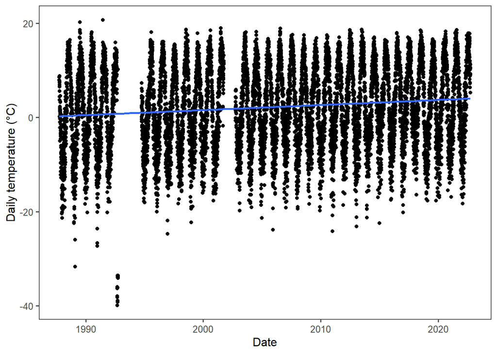

```r
ggplot(snotel_408_clean_culled, aes(x = Date, y = temperature_mean)) +
  geom_point() + #lwd = 2) +
  theme_few() +
  geom_smooth(method = "lm", se=FALSE) +
  ylab('Daily temperature (°C)') +
  xlab('Date')
```

```r
temp_408_xts <- xts(snotel_408_clean_culled$temperature_mean, order.by = snotel_408_clean_culled$Date)

dygraph(temp_408_xts) %>%
  dyAxis("y", label = "Daily mean temperature (°C)")
```

[interactive chart not shown]

```r
snotel_408_clean_culled <- snotel_408_clean_culled %>%
  filter(temperature_mean > -30)

temp_408_xts <- xts(snotel_408_clean_culled$temperature_mean, order.by = snotel_408_clean_culled$Date)

dygraph(temp_408_xts) %>%
  dyAxis("y", label = "Daily mean temperature (°C)")
```

[interactive chart not shown]

### Columbine 408 *Morrisey* 7/22/2005

```r
snotel_408_adjusted <- snotel_408_clean_culled %>%
  mutate(temp_ad = if_else(Date < "2005-07-22", ((5.3*10^(-7))*(temperature_mean^(4))+(3.72*10^(-5))*(temperature_mean^(3))-(2.16*10^(-3))*(temperature_mean^(2))-(7.32*10^(-2))*(temperature_mean)+1.37)+temperature_mean, temperature_mean))
```

Non-corrected

#### 408 Detrended

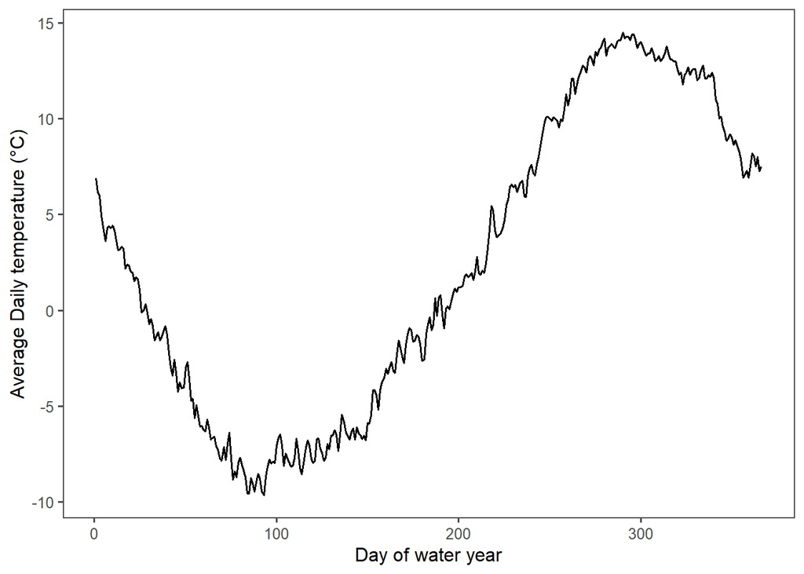

```r
#using the clean culled df:

#average water year temperature

yearly_wy_aver_408 <- snotel_408_adjusted %>%
  group_by(waterYear) %>%
  mutate(aver_ann_temp = mean(temperature_mean))

#Average temperature by day for all water years:

daily_wy_aver_408 <- yearly_wy_aver_408 %>%
  group_by(daymonth) %>%
  mutate(aver_day_temp = mean(aver_ann_temp))

#average mean temperature by day for the period of record:

daily_wy_aver_408 <- daily_wy_aver_408 %>%
  group_by(daymonth) %>%
  mutate(all_ave_temp = mean(daily_wy_aver_408$aver_day_temp))

# try to show all years as means.
daily_wy_aver2_408 <-daily_wy_aver_408 %>%
  group_by(waterDay) %>%
  mutate(date_temp = mean(temperature_mean))


daily_wy_aver2_408$date_temp <- signif(daily_wy_aver2_408$date_temp,3) #reduce the sig figs


ggplot(daily_wy_aver2_408, aes(x = waterDay, y = date_temp))+
  geom_line(size= 0.7) +
  theme_few() +
  ylab('Average Daily temperature (°C)') +
  xlab('Day of water year')
```

#### 408 SD

```r
standard_dev_408 <- daily_wy_aver_408 %>%
  group_by(waterYear) %>%
  mutate(residual = (all_ave_temp-aver_ann_temp)+temperature_mean-aver_day_temp) %>%
  mutate(deviation = abs(residual-lag(residual)))

standard_dev_all_408 <- standard_dev_408 %>%
  group_by(waterYear) %>%
  mutate(nmbr = n())

standard_dev_all_408 <- standard_dev_all_408 %>%
  group_by(waterYear) %>%
  mutate(resid_mean = mean(residual)) %>%
  mutate(sd_1 = residual-resid_mean) %>%
  mutate(sd_2 = (((sum((sd_1)^2))/((nmbr-1))))^(0.5)) %>%
  distinct(sd_2, .keep_all = TRUE) %>%
   select(waterYear, sd_2)

standard_dev_all_408 %>%
  kable(.,'html') %>%
  kable_styling() %>%
  scroll_box(width='250px',height='500px')
```

| waterYear | sd_2 |
| --- | --- |
| 1988 | 9.911311 |
| 1989 | 9.479817 |
| 1990 | 8.845588 |
| 1991 | 9.141713 |
| 1992 | 8.235717 |
| 1995 | 8.387811 |
| 1996 | 8.807923 |
| 1997 | 8.867338 |
| 1998 | 9.074387 |
| 1999 | 8.232888 |
| 2000 | 8.585091 |
| 2001 | 9.380546 |
| 2003 | 8.847298 |
| 2004 | 8.495495 |
| 2005 | 8.135796 |
| 2006 | 8.734304 |
| 2007 | 8.839901 |
| 2008 | 8.888992 |
| 2009 | 7.926154 |
| 2010 | 8.738675 |
| 2011 | 8.455577 |
| 2012 | 8.702054 |
| 2013 | 9.110505 |
| 2014 | 8.268271 |
| 2015 | 7.870630 |
| 2016 | 8.492743 |
| 2017 | 8.238399 |
| 2018 | 8.140089 |
| 2019 | 8.644103 |
| 2020 | 9.027143 |
| 2021 | 8.902353 |
| 2022 | 8.706784 |

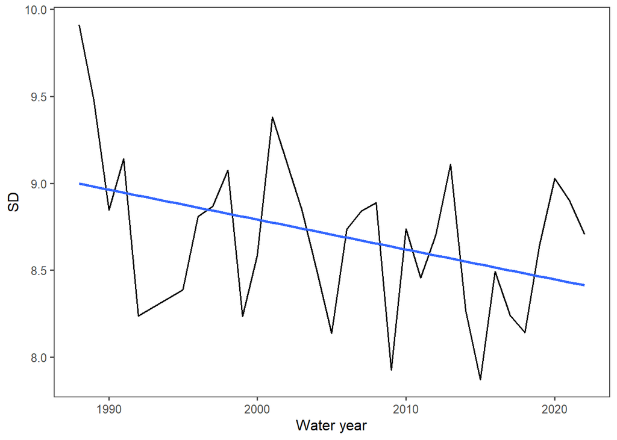

```r
ggplot(standard_dev_all_408, aes(x = waterYear, y = sd_2))+
  geom_line(size= 0.7) +
  theme_few() +
  geom_smooth(method = "lm", se=FALSE) +
  ylab('SD') +
  xlab('Water year')
```

#### MK & SS for 408 (non-corrected)

```r
sd_mk_408 <- mk.test(standard_dev_all_408$sd_2)
print(sd_mk_408)
```

```
##
##  Mann-Kendall trend test
##
## data:  standard_dev_all_408$sd_2
## z = -1.7676, n = 32, p-value = 0.07713
## alternative hypothesis: true S is not equal to 0
## sample estimates:
##            S         varS          tau
## -110.0000000 3802.6666667   -0.2217742
```

```r
sd_sens_408 <- sens.slope(standard_dev_all_408$sd_2)
print(sd_sens_408)
```

```
##
##  Sen's slope
##
## data:  standard_dev_all_408$sd_2
## z = -1.7676, n = 32, p-value = 0.07713
## alternative hypothesis: true z is not equal to 0
## 95 percent confidence interval:
##  -0.033742130  0.001027723
## sample estimates:
## Sen's slope
## -0.01615257
```

#### 408 Detrended (corrected)

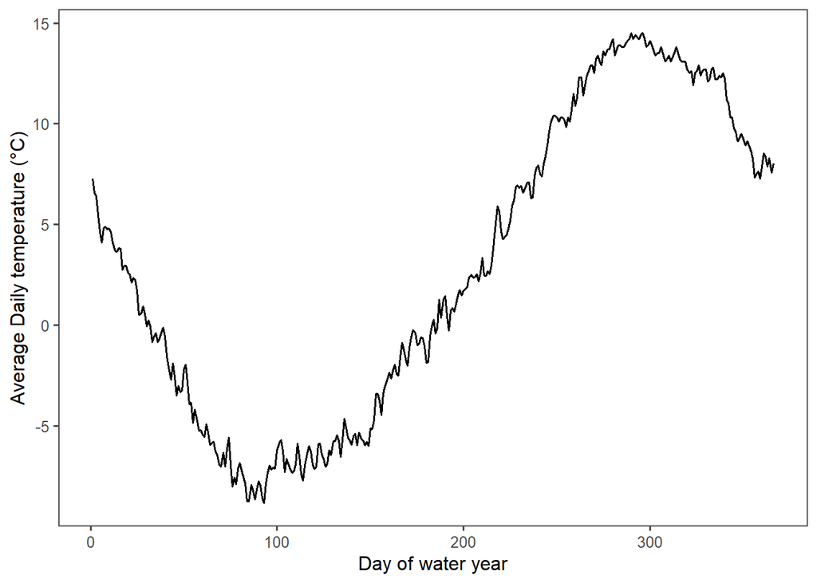

```r
#using the clean culled df:
#average water year temperature
yearly_wy_aver_408_ad <- snotel_408_adjusted %>%
  group_by(waterYear) %>%
  mutate(aver_ann_temp_ad = mean(temp_ad))
#Average temperature by day for all water years:
daily_wy_aver_408_ad <- yearly_wy_aver_408_ad %>%
  group_by(daymonth) %>%
  mutate(aver_day_temp_ad = mean(aver_ann_temp_ad))
#average mean temperature by day for the period of record:
daily_wy_aver_408_ad <- daily_wy_aver_408_ad %>%
  group_by(daymonth) %>%
  mutate(all_ave_temp_ad = mean(daily_wy_aver_408_ad$aver_day_temp_ad))
# try to show all years as means.
daily_wy_aver2_408_ad <-daily_wy_aver_408_ad %>%
  group_by(waterDay) %>%
  mutate(date_temp_ad = mean(temp_ad))

daily_wy_aver2_408_ad$date_temp_ad <- signif(daily_wy_aver2_408_ad$date_temp_ad,3) #reduce the sig figs
ggplot(daily_wy_aver2_408_ad, aes(x = waterDay, y = date_temp_ad))+
  geom_line(size= 0.7) +
  theme_few() +
  ylab('Average Daily temperature (°C)') +
  xlab('Day of water year')
```

#### 408 SS (corrected)

```r
standard_dev_408_ad <- daily_wy_aver_408_ad %>%
  group_by(waterYear) %>%
  #filter(waterYear >= 1987 & waterYear <= 2021) %>%
  mutate(residual = (all_ave_temp_ad-aver_ann_temp_ad)+temp_ad-aver_day_temp_ad) %>%
  mutate(deviation = abs(residual-lag(residual)))
standard_dev_all_408_ad <- standard_dev_408_ad %>%
  group_by(waterYear) %>%
  mutate(nmbr = n())
standard_dev_all_408_ad <- standard_dev_all_408_ad %>%
  group_by(waterYear) %>%
  mutate(resid_mean = mean(residual)) %>%
  mutate(sd_1 = residual-resid_mean) %>%
  mutate(sd_2 = (((sum((sd_1)^2))/((nmbr-1))))^(0.5)) %>%
  distinct(sd_2, .keep_all = TRUE) %>%
   select(waterYear, sd_2)
standard_dev_all_408_ad %>%
  kable(.,'html') %>%
  kable_styling() %>%
  scroll_box(width='250px',height='500px')
```

| waterYear | sd_2 |
| --- | --- |
| 1988 | 9.255004 |
| 1989 | 8.873391 |
| 1990 | 8.216764 |
| 1991 | 8.545580 |
| 1992 | 7.664569 |
| 1995 | 7.780528 |
| 1996 | 8.186934 |
| 1997 | 8.260524 |
| 1998 | 8.410419 |
| 1999 | 7.651225 |
| 2000 | 7.928801 |
| 2001 | 8.691699 |
| 2003 | 8.174582 |
| 2004 | 7.895518 |
| 2005 | 7.482674 |
| 2006 | 8.735962 |
| 2007 | 8.841502 |
| 2008 | 8.890875 |
| 2009 | 7.928502 |
| 2010 | 8.741101 |
| 2011 | 8.457260 |
| 2012 | 8.703940 |
| 2013 | 9.112301 |
| 2014 | 8.270874 |
| 2015 | 7.872234 |
| 2016 | 8.495258 |
| 2017 | 8.239886 |
| 2018 | 8.142322 |
| 2019 | 8.646452 |
| 2020 | 9.028953 |
| 2021 | 8.904182 |
| 2022 | 8.708980 |

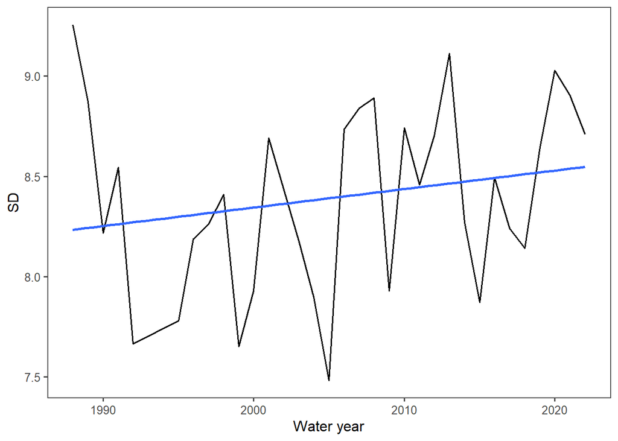

```r
ggplot(standard_dev_all_408_ad, aes(x = waterYear, y = sd_2))+
  geom_line(size= 0.7) +
  theme_few() +
  geom_smooth(method = "lm", se=FALSE) +
  ylab('SD') +
  xlab('Water year')
```

#### MK & SS 408 (corrected)

```r
sd_mk_408_ad <- mk.test(standard_dev_all_408_ad$sd_2)
print(sd_mk_408_ad)
```

```
##
##  Mann-Kendall trend test
##
## data:  standard_dev_all_408_ad$sd_2
## z = 1.2487, n = 32, p-value = 0.2118
## alternative hypothesis: true S is not equal to 0
## sample estimates:
##            S         varS          tau
##   78.0000000 3802.6666667    0.1572581
```

```r
sd_sens_408_ad <- sens.slope(standard_dev_all_408_ad$sd_2)
print(sd_sens_408_ad)
```

```
##
##  Sen's slope
##
## data:  standard_dev_all_408_ad$sd_2
## z = 1.2487, n = 32, p-value = 0.2118
## alternative hypothesis: true z is not equal to 0
## 95 percent confidence interval:
##  -0.007349474  0.033195852
## sample estimates:
## Sen's slope
##  0.01316118
```